# Exe2

2024-04-16

*Exercise 1* - Discrete random variable

- The probability distribution function of a discrete variable *k* is given by the *zero-truncated* Poisson distribution:
  $$P(k) = \frac{\lambda^k e^{- \lambda}}{k! (1 - e^{-\lambda})}$$
1. Write the R functions for the probability density and cumulative distribution functions, using the R naming convention.
- Assuming $\lambda = 1.4$,
2. Produce two plots showing the pdf and cdf, separately.

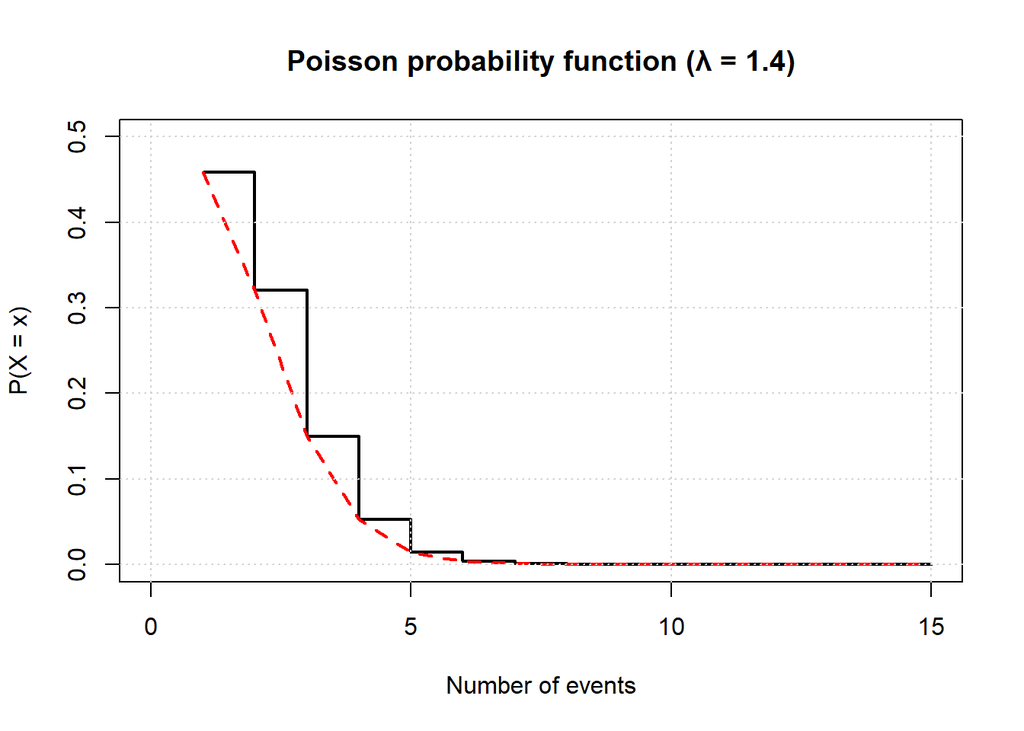

```r
## First let's define the zero truncated poisson function
## Remember that x is indeed a vector of n components

dpoisz <- function(x, lambda) {
    pmf <- (lambda^x * exp(-lambda) / (factorial(x) * (1 - exp(-lambda))))
  return(pmf)
}

## Let's now define the cumulative distribution function

ppoisz <- function(k, lambda) {

  cdf <- rep(0, length(k))

  for (i in 1:length(k)) {
    cdf[i] <- sum(dpoisz(1:k[i], lambda))

  }
  return(cdf)
}


N_samples <- 100

x <- 1:15
lambda <- 1.4


plot(dpoisz(x, lambda), type = 's', lwd = 2,
     main = 'Poisson probability function (λ = 1.4)',
     ylab = 'P(X = x)', xlab = 'Number of events',
     ylim = c(0, 0.5),
     xlim = c(0, 15)
     )

lines(dpoisz(x, lambda), type = 'l', lty = 2, lwd = 2, col = 'red')
grid()
```

```r
#legend('topright', legend = 'λ = 1.4', col = 'black', lwd = 1, bty = 'n')
```

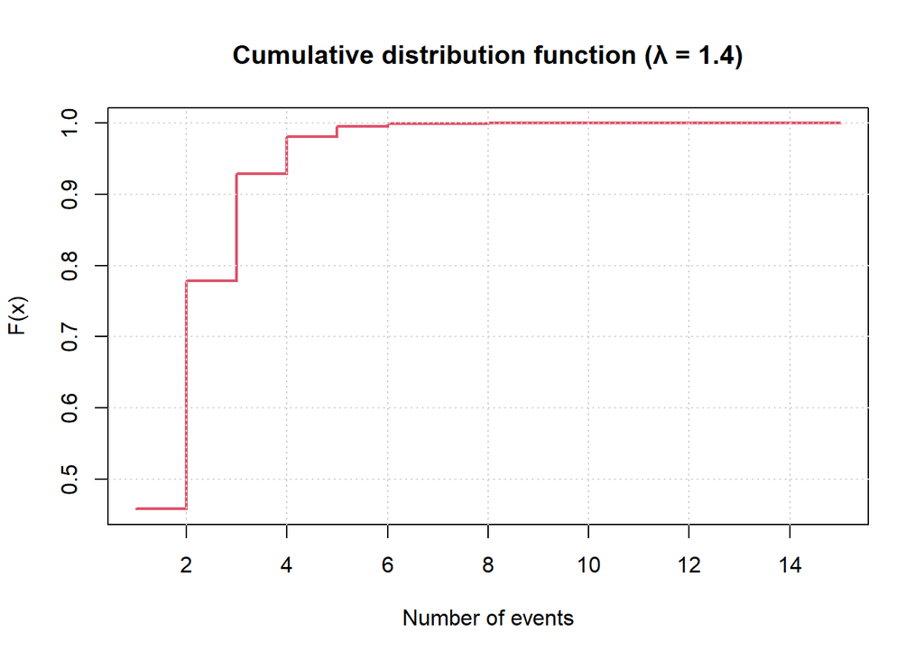

```r
#-----------
# lambda: 1.4
#-----------
lambda <- 1.4
k <- 1:15


plot(ppoisz(k, lambda), type = "s", lwd = 2,
     main = "Cumulative distribution function (λ = 1.4)",
     xlab = "Number of events", ylab = "F(x)", col = 2,
     ylim = c(min(ppoisz(k, lambda)), max(ppoisz(k, lambda)))
     )

grid()
```

3. Compute the mean value and variance of the probability distribution using R.

```r
k <- 0:100
pdf <- dpoisz(k, lambda)
pdf.2 <- dpoisz(k^2, lambda)

mean_value <- sum(k * dpoisz(k, lambda))


print(sprintf('Mean: %.3f', mean_value))
```

```
## [1] "Mean: 1.858"
```

```r
std_value <- sum(k^2 * dpoisz(k, lambda)) - mean_value^2


print(sprintf('Variance: %.3f', std_value))
```

```
## [1] "Variance: 1.007"
```

4. Generating a sample of random numbers from the given distribution

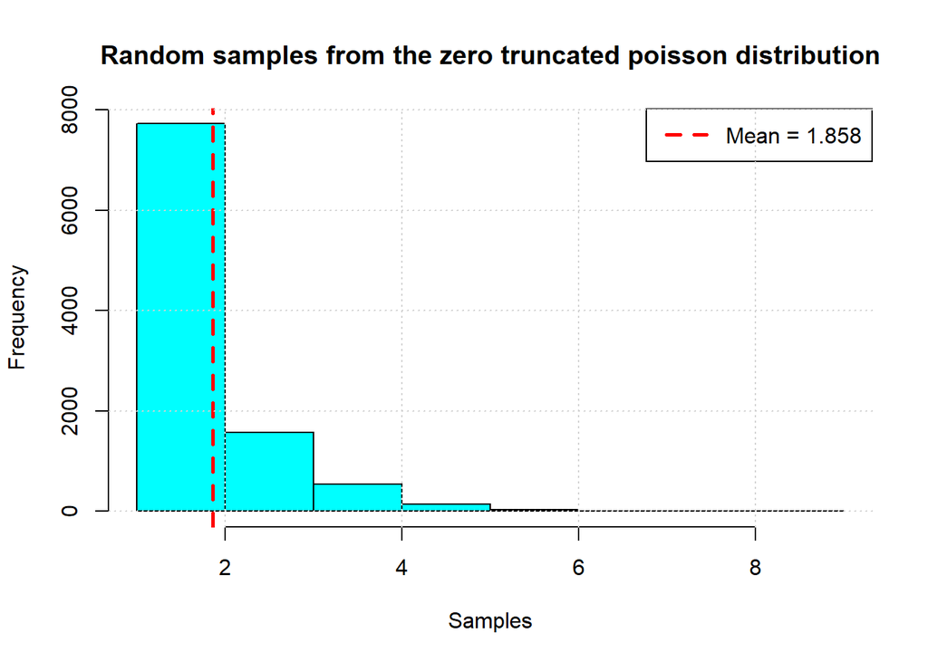

```r
k <- 1:1000
samples <- sample(k, size = 10000, replace = TRUE, prob = dpoisz(k, lambda))


hist(samples,
     breaks = seq(min(samples), max(samples), by = 1),
     main = 'Random samples from the zero truncated poisson distribution',
     xlab = 'Samples', ylab = 'Frequency',
     col = 'cyan')


abline(v = mean_value, col = 'red', lty = 2, lw = 2.5)
#lines(dpoisz(k, lambda), type = 'l', lty = 2, lwd = 2, col = 'black')
legend('topright', legend = sprintf('Mean = %.3f', mean_value), col = 'red', lty = 2, lw = 2.5)
grid()
```

*Exercise 2* - Continuous random variable

- The energy distribution of CR muons at sea level can be approximated as follows:

$$\begin{cases}
p(E) = N \ \ &for \ \ E < E_0 \\
p(E ) = (E - E_0 + 1) ^ {- {\gamma}} \ \ &for \ \ E\ \ge \ E_0
\end{cases}$$

where $E_0 \ =\ 7.25\ GeV$ and $\gamma\ =\ 2.7$.

1. Compute the normalization factor N using R.
2. Plot the probability density function in R.
3. Plot the cumulative density function in R.
4. Compute the mean value using R.
5. [ $\textbf{Optional}$ ] Generate $10^6$ random numbers from this distribution, show them in an histogram and superimpose the pdf ( with a line or with a sufficient number of points).

```r
## R Markdown
# To compute the normalization factor we need the integral
# Let's first define the probability distribution

p <- function(E, N, E_0, gamma) {
  if (E < E_0) {
    return(N)
  } else {
    return(N * (E - E_0 + 1) ^ (-gamma))
  }
}

E_0 <- 7.25
gamma <- 2.7

n_steps <- 100
dE <- E_0 / n_steps

## First we need to compute the integral of the distribution
summ <- 0
for (i in n_steps) {
  summ <- summ + p(dE, N = 1, E_0, gamma)
}

N <- summ / E_0

print(sprintf('Normalization factor: %.3f ', N))
```

```
## [1] "Normalization factor: 0.138 "
```

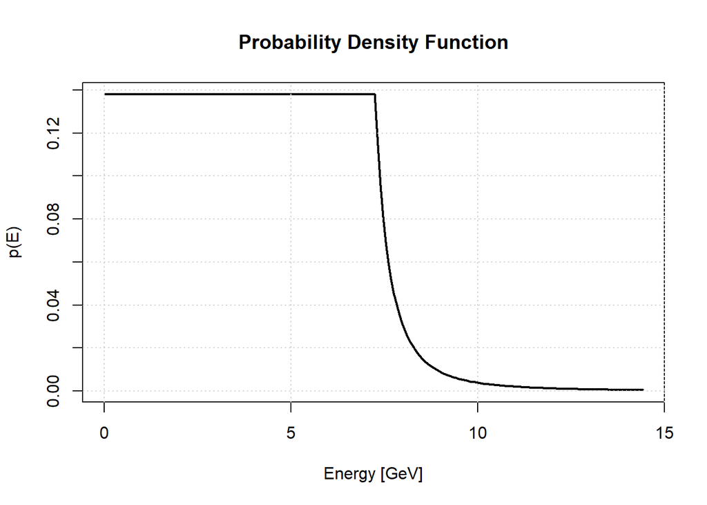

```r
## Let's plot the probability density function in R
N_steps <- 100

E <- 0
dE <- E_0 / N_steps
E_stored <- numeric(N_steps * 2)
pdf <- numeric(N_steps * 2)

for (i in 1:(N_steps * 2)) {
  E_stored[i] <- E
  pdf[i] <-  p(E, N, E_0, gamma)
  E <- E + dE
}

plot(E_stored, pdf,
     xlab = 'Energy [GeV]',
     ylab = 'p(E)',
     type  ='l', lwd = 2,
     main = 'Probability Density Function')
grid()
```

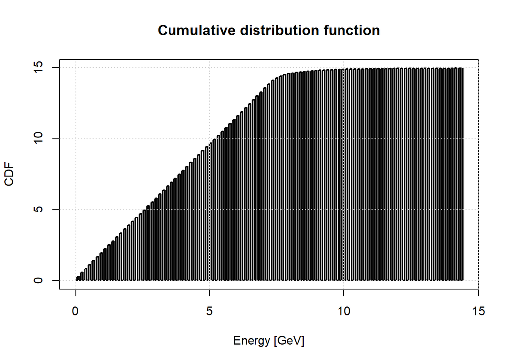

```r
CDF <- numeric(N_steps * 2)

for (i in (1:N_steps * 2)) {
  CDF[i] <- sum(pdf[0:i])
}

plot(E_stored, CDF, type = 's',
     xlab = 'Energy [GeV]', ylab = 'CDF',
     main = 'Cumulative distribution function',
     col = 'black', lwd = 2)
grid()
```

```r
## Compute the mean

E.x.1 <- integrate(function(E) {N * E}, lower = 0, upper = E_0)$value

E.x.2 <- integrate(function(E) {N * E * (E - E_0 + 1)^(-gamma)}, lower = E_0, upper = Inf)$value

integral <- E.x.1 + E.x.2
print(paste(sprintf('Mean of the distribution: %.3f', E.x.1 + E.x.2), 'GeV'))
```

```
## [1] "Mean of the distribution: 4.329 GeV"
```

*Exercise 3* - Suppose that the average number of accidents at an intersection is two per day.

1. Using Markov’s inequality, find a bound for the probability that at least five accidents will occur tomorrow.

From Markov’s inequality we know that

$$P(X \ge k) \le \frac{\mu}{k}$$

Applying in our case:

$$P(X \ge 5) \le \frac{2}{5}$$

b. Using Poisson random variables, calculate the probability that at least five accidents will occur tomorrow. Compare this value with the bound obtained in the previous point a).

Using a Poisson random variable we define:

$$P(X \ge 5) = 1 - P(X \le 4)$$

c. Let the variance of the number of accidents be two per day. Using Chebyshev’s inequality, find a bound on the probability that tomorrow at least five accidents will occur.

Now applying the Chebyshev’s inequality:

$$P(|X \ - \ \mu| \ \ge k) \le \frac{\sigma^2}{k^2}$$

where, in our case:

$$\begin{cases}
Var(X) &= &2 \\
\mu &= &2
\end{cases}$$

then:

$$P(X \ - \ 2 \ge k) \ \le \ P(X - 2 \ge k) \ + \ P(-X \ + \ 2 \le - \
k) \ = \ P(|X - 2| \ge \ k)$$

so we apply the Chebishev’s inequality with k = 3:

$$P(|X \ - \ 2| \ \ge \ 3) \le \frac{2}{9}$$

```r
## First let's use Markov's inequality

avg_acc <- 2
prob <- avg_acc / 5

print(paste('The probability of having at least 5 accidents is', prob * 100, '%'))
```

```
## [1] "The probability of having at least 5 accidents is 40 %"
```

```r
## Now let's assume that each accident is described by a Poisson variable with lambda = 2

lambda <- 2

## P(N(t) = n) = (lambda * t)^n * e^(-5t) / n! with t = 24/24 (tomorrow) = 1
## P(N(1) >= 5) = 1 - P(N(1) = 0) - P(N(1) = 1) - P(N(1) = 2) - P(N(1) = 3) - ...

poisson_prob <- ppois(4, lambda)
print(paste(sprintf('The probability given by the Poisson distribution is: %.2f ', (1 - poisson_prob)* 100), '%'))
```

```
## [1] "The probability given by the Poisson distribution is: 5.27  %"
```

```r
## Now let's use the Chebishev's inequality

var_x <- 2 # -> sigma = 1
mu_x <- 2

## P(|x - mu| >= r sigma) <= var/r^2 sigma^2 = 1/r^2
## Nel nostro caso sigma = 1, |x - mu| >= 3 sigma

cheb_prob <- 2 / 9

print(paste(sprintf('The Chebishev\'s upper bound is of: %.2f', cheb_prob * 100), '%'))
```

```
## [1] "The Chebishev's upper bound is of: 22.22 %"
```

*Exercise 4* - The waiting period from the time a book is ordered until it is received is a random variable with mean seven days and standard deviation two days. If Helen wants to be 95% sure that she receives a book by a certain date, how early should she order the book?

As before we can apply Chebyshev’s inequality:

$$P(|X \ - \mu| \ge \ r\sigma) \le \frac{1}{r^2} \ \\
P(|X \ - \mu| \le \ r \sigma) = 1 - P(|X \ - \mu| \ \ge \ r\sigma)
\le \ 1 - \frac{1}{r^2} = 0.95 \\
\rightarrow \frac{1}{r^2} \ = 1 - 0.95 = 0.05 \rightarrow \ r =
\sqrt(\frac{10^2}{5})$$

```r
mu_x <- 7 #days
sigma_x <- 2

## P(|x - mu_x| <- sigma_x ) = 0.95
## P(|x - mu_x| < r sigma) >= 1 - 1/r^2 = 0.95 -> r = sqrt(10^2 /5)
## |x - 7| < r sigma -> x > 7 - r sigma

r <- sqrt(10^2 / 5) # Z score = z * sigma (?? not sure)
x <- mu_x + r * sigma_x

print(paste(sprintf('She should order it at least: %.0f', x), 'days before'))
```

```
## [1] "She should order it at least: 16 days before"
```

*Exercise 5* - An ordinary deck of 52 cards is divided randomly into 26 pairs. Using Chebyshev’s inequality, find an upper bound for the probability that, at most, 10 pairs consist of a black and a red card.

```r
# 10 coppie devono essere formate da una carta nera ed una rossa
# 26 coppie possibili: 10 / 26 devono essere accoppiate
# P(|x - mu_x| >= r*sigma) <= 1 / r^2
# mu_x = 13
# sigma^2 = np(1-p) = 26 * (26/52 * 26/51) * (1 - 26/52 * 26/51)
# k = |10 -mu| / sigma =  3 / sigma^2
## Let's simulate the deck

Generating_deck <- function() {
  N <- 52
  mazzo <- c(rep(0, N/2), rep(1, N/2))
  mazzo <- mazzo[sample(length(mazzo))]
  y <- 0
  for (i in 1:(N/2)){
    if (mazzo[i] + mazzo[i+N/2] == 1){
      y <- y + 1
    }
  }
  return(y)
}

N_campioni <- 100000
campioni <- rep(0, N_campioni)
for (i in 1:N_campioni) {
  campioni[i] <- Generating_deck()
}

hist(campioni, breaks = seq(min(campioni) - 0.5,
                            max(campioni) + 0.5, by = 1), main = 'Samples distribution', xlab = 'Samples', ylab = 'Frequency')

media <- mean(campioni)
deviazione_standard <- sd(campioni)
delta <- 10 - media
k <- delta / deviazione_standard
limite_superiore <- 1 / k^2

abline(v = media, col = 'red', lty = 2, lw = 2.5)
abline(v = c(media - deviazione_standard, media + deviazione_standard), col = "black", lty = 2, lw = 1)
print(paste(sprintf('The upper bound given by Chebyshev is of: %.2f', limite_superiore * 100), '%'))
```

```
## [1] "The upper bound given by Chebyshev is of: 62.46 %"
```

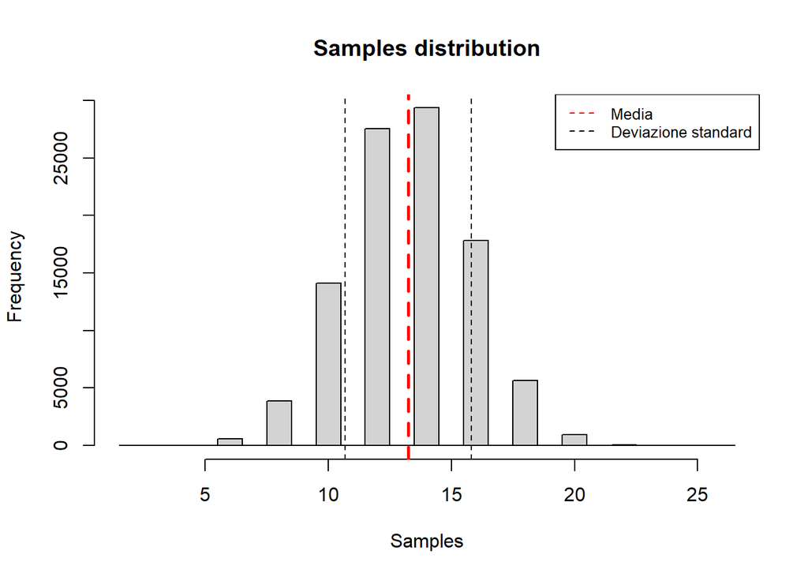

```r
legend('topright', legend = c('Media', 'Deviazione standard'),
       col = c('red', 'black'), lty = 2, cex = 0.8)
```

*Exercise 6* - In a stationary bus at the departure station, a passenger gets on the bus, on average, every 30 seconds.

1. Compute the probability of getting more than 6 passengers after 2 minutes. Evaluate the probability of having less than 4 passengers after 3 minutes.

b. Simulate the distribution of the arrival time of the third passenger and superimpose the corresponding pdf.

The arrival time of the passengers can be represented with an exponential distribution where:

$$\Delta t_i = Exp(\lambda) \ \rightarrow \ T_3 = \sum_{i=1}^3 \Delta t_i$$

where $T_3$ is the arrival time of the third passenger. The sum of the components will be distributed as the Erlang distribution.

c. Repeat the procedure of point b) for the difference in arrival time between the fifth and the first passenger.

Now we evaluate the time difference, also distributed as an Erlang distribution:

$$\Delta T = T_5 \ - \ T_1 = \sum_{i=1}^5\Delta t_i \ - \ \Delta t_1 =
\sum_{i=1}^4 \Delta t_i$$

```r
## Consideriamo eventi scorrelati, ogni evento è indipendente dagli altri

lambda <- 1/30.

prob1 <- 1 - ppois(6, lambda * 120) #seconds
prob2 <- ppois(4, lambda * 180)

print(paste(sprintf('The probability of getting more than 6 passengers after 2 minutes is of: %.2f', prob1 * 100), '%'))
```

```
## [1] "The probability of getting more than 6 passengers after 2 minutes is of: 11.07 %"
```

```r
print(paste(sprintf('The probability of having less than 4 passengers after 3 minutes is given by: %.2f', prob2 * 100), '%'))
```

```
## [1] "The probability of having less than 4 passengers after 3 minutes is given by: 28.51 %"
```

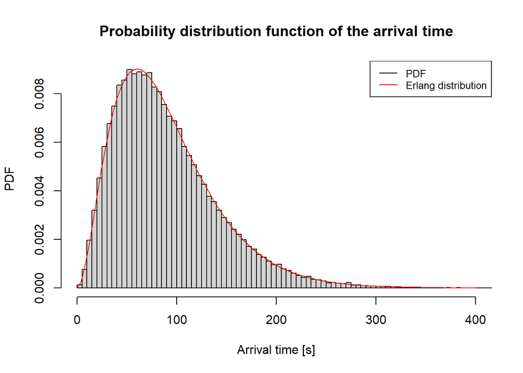

```r
## Now generating the arrival times of the passengers

arrivals <- function() {
  dt1 <- rexp(1, lambda)   #x rappresenta la variabile temporale
  dt2 <- rexp(1, lambda)
  dt3 <- rexp(1, lambda)

  time <- dt1 + dt2 + dt3
  return(time)
}


N_samples <- 100000
time <- c(rep(0, N_samples))
for (i in 1:N_samples) {
  time[i] <- arrivals()
}

x <- 0:N_samples

hist(time, breaks = 'FD',
     probability = TRUE, xlab = 'Arrival time [s]', ylab = 'PDF',
     main = 'Probability distribution function of the arrival time', xlim = c(0, 400))

curve(dgamma(x, shape = 3, rate = lambda), col = 'red', add = TRUE, xlim = c(0, 400))
legend('topright', legend = c('PDF', 'Erlang distribution'),
       col = c('black', 'red'), lty = 1, cex = 0.8)
```

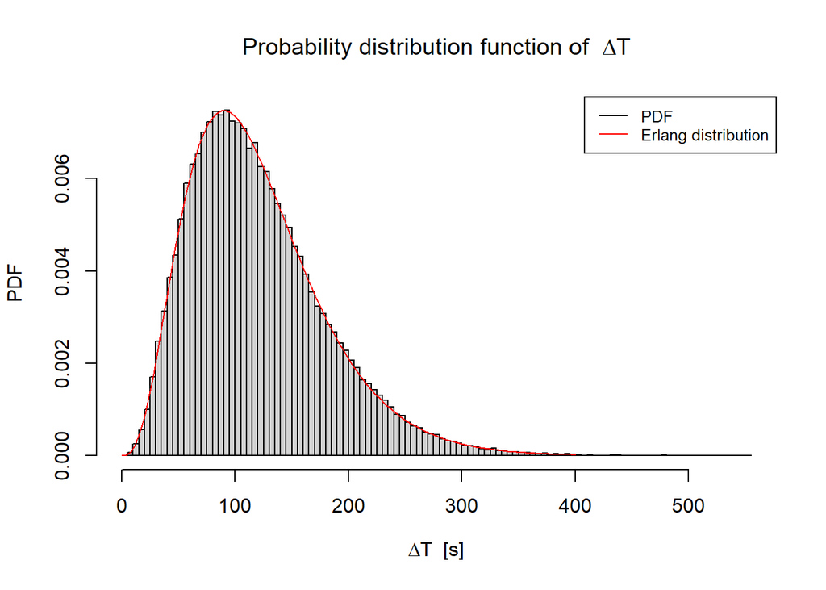

```r
## Repeating the same steps as point b) but evaluating the difference of time between fifth and first passenger

arrivals.2 <- function() {
  dt1 <- rexp(1, lambda)
  dt2 <- rexp(1, lambda)
  dt3 <- rexp(1, lambda)
  dt4 <- rexp(1, lambda)
  dt5 <- rexp(1, lambda)

  T1 <- dt1
  T5 <- dt1 + dt2 + dt3 + dt4 + dt5

  DT <- T5 - T1

  return(DT)
}

N_samples.2 <- 100000
time.2 <- c(rep(0, N_samples.2))
for (i in 1:N_samples.2) {
  time.2[i] <- arrivals.2()
}

x <- 0:N_samples.2
hist(time.2, breaks = 'FD',
     probability = TRUE, xlab = expression(Delta * 'T \ [s]'), ylab = 'PDF',
     main = expression('Probability distribution function of \ ' * Delta * 'T'))
curve(dgamma(x, shape = 4, rate = lambda), col = 'red', add = TRUE, xlim = c(0, 400))
legend('topright', legend = c('PDF', 'Erlang distribution'),
       col = c('black', 'red'), lty = 1, cex = 0.8)
```